# example_2_transformations

Anni Hong

1/12/2021

## Todo:

- add the range rule for selecting variables considered for transformation
- add the min-p transformation selection procedure
- add the min-p transformation selection procedure to select cut points
- use CPMCGLM as remedies
- multiple testing control for selecting the number of cutpoints as well as the location of the cutpoints [Determining the optimal number and location of cutoff points with application to data of cervical cancer](https://journals.plos.org/plosone/article?id=10.1371/journal.pone.0176231#abstract0)
- summarize different types of transformation used in practice

## Automatic Choice of Transformation of Predictors

Weisberg, S. (2014). Applied linear regression. Hoboken, NJ: Wiley.

(Weisberg, 2014) Chapter 8 Transformations - Power transformation: $U^{\lambda}$ where $\lambda \in [-2,2]$ usually {-1,0,1/3,1/2}, 0 means log transformation here.

**The log rule** If the values of a variable range over more than one order of magnitude and the variable is strictly positive, then replacing the variable by its logarithm is likely to be helpful.

**The range rule** If the range of a variable is considerably less than one order of magnitude, then any transformation of that variable is unlikely to be helpful.

- Scaled power transformations preserve the direction of association, in the sense that if (X, Y) are positively related, then (psi(X, lambda), Y) are positively related for all values of lambda. With basic power transformations, the direction of association changes when lambda < 0.
  $$\Psi(X, \lambda) = \frac{X^\lambda -1}{\lambda}, \lambda \neq 0$$
  $$= log(X), \lambda = 0$$
  If we know λ, we can fit (8.4) via ols and get the residual sum of squares, RSS(λ). An estimate λˆ of λ is the value of λ that minimizes RSS(λ). We do not need to know λ very precisely, and selecting λ to minimize RSS(λ) from λ ∈ {−1, −1/2, 0, 1/3, 1/2, 1} is usually adequate.
- The Box–Cox method is not transforming for linearity, but rather it is trans- forming for normality:
- transformations for many predictors at the same time.
1. Transform predictors to get regressors for which the condition for lin- early related regressors holds, at least approximately. The regressors in X may include dummy variables that represent factors, which should not be transformed, as well as transformations of continuous predictors.
2. We can estimate g from the 2D scatterplot of Y versus b′x, where b is the ols estimator from the regression of Y on X. Almost equivalently, we can estimate a transformation of Y either from the inverse plot of b ′x versus Y or from using the Box–Cox method.
- 8.2.2 Automatic Choice of Transformation of Predictors V(λ) be the sample covariance matrix of the transformed data ψM(X, ˆ λ). The value l is selected as the value of λ that minimizes the logarithm of the determinant of V(λ).

```r
bootstrap_process <- function(data_gen, B, outcome, covariates, m=nrow(data), to_shuffle = T){
  train_res <- list()
  test_res <- list()
  for (i in 1:B){
    dat <- data_gen(outcome, m, to_shuffle)
    split <- sample_splitting(dat)
    ls <- get_lambdas(split$train, outcome)
    fit_train <- post_transform_inference(split$train, outcome, covariates, ls)
    fit_test <- post_transform_inference(split$test, outcome, covariates, ls)
    train_res[[i]] <- fit_train
    test_res[[i]] <- fit_test
  }
  res <- list(train_res = train_res, test_res = test_res)
  return(res)
}
```

```r
train_prop <- c()
test_prop <- c()
train_prop_sandwich <- c()
test_prop_sandwich <- c()
B = 100
sample_size_seq <- seq(from=400,to=800, by=100)
for (size in sample_size_seq){
  print(size)
  r <- bootstrap_process(make_data, B, "y", paste0("x",c(1:10)), size, F)
  train_res <- r$train_res
  test_res <- r$test_res

  #lm variance
  train_sig <- purrr::map(train_res,get_num_sig,robust=F)
  test_sig <- purrr::map(test_res,get_num_sig,robust=F)
  train_prop <- c(train_prop, mean(train_sig > 0))
  test_prop <- c(test_prop, mean(test_sig > 0))

  #robust variance
  train_sig_sandwich <- purrr::map(train_res,get_num_sig,robust=T)
  test_sig_sandwich <- purrr::map(test_res,get_num_sig,robust=T)
  train_prop_sandwich <- c(train_prop_sandwich, mean(train_sig_sandwich > 0))
  test_prop_sandwich <- c(test_prop_sandwich, mean(test_sig_sandwich > 0))
}
```

```
## [1] 400
## [1] 500
```

```
## [1] 600
## [1] 700
## [1] 800
```

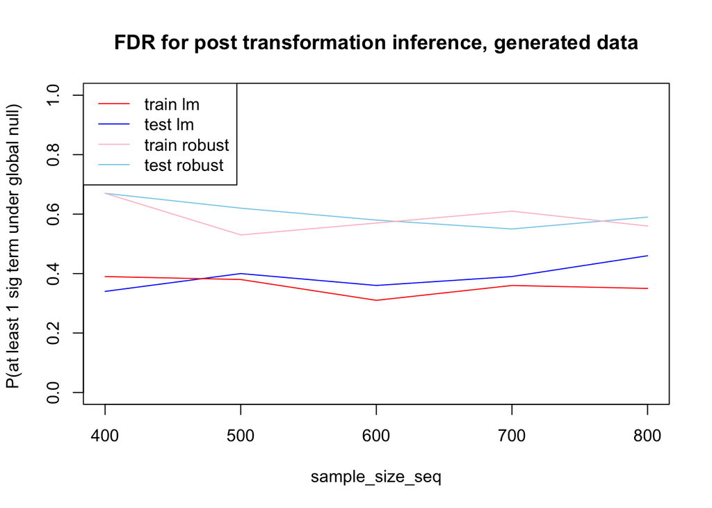

```r
#par(mfcol=c(2,1))
plot(sample_size_seq, test_prop, type = "l", col="blue", ylim = c(0,1), ylab = "P(at least 1 sig term under global null) ", main = "FDR for post transformation inference, generated data")
lines(sample_size_seq,train_prop, col="red")
lines(sample_size_seq,test_prop_sandwich, col="skyblue")
lines(sample_size_seq,train_prop_sandwich, col="pink")
legend("topleft", legend=c("train lm", "test lm", "train robust", "test robust"),col=c("red", "blue", "pink", "skyblue"), lty=1:1, cex=1)
```

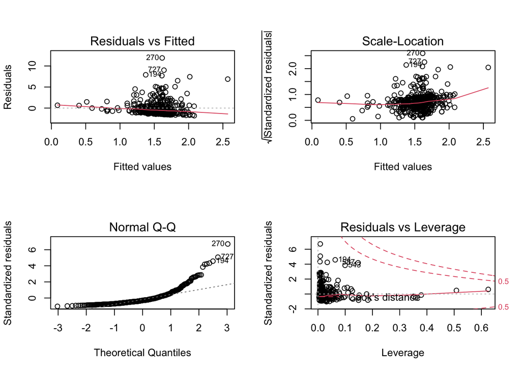

```r
par(mfcol=c(2,2))
plot(train_res[[sample(length(train_res),1)]])
```

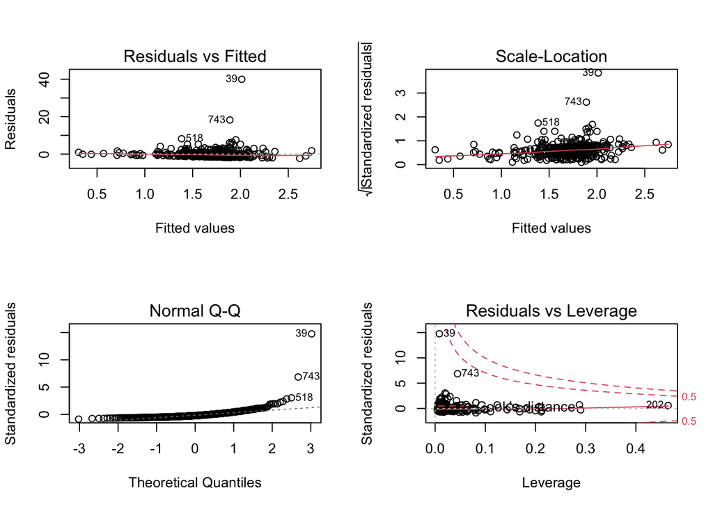

```r
plot(test_res[[sample(length(test_res),1)]])
```

## Using Boston Housing dataset

```r
dat <- Boston[,-c(2,4)]
boston_data_shuffle_sample <- bootstrap_shuffle_factory(dat)
outcome <- "medv"
covariates <- colnames(dat)[-which(colnames(dat) == outcome)]

train_prop <- c()
test_prop <- c()
train_prop_sandwich <- c()
test_prop_sandwich <- c()
B = 200
sample_size_seq <- seq(from=1000,to=2000, by=250)
for (size in sample_size_seq){
  print(size)
  r <- bootstrap_process(boston_data_shuffle_sample, B, outcome, covariates, B, size)
  train_res <- r$train_res
  test_res <- r$test_res

  #lm variance
  train_sig <- purrr::map(train_res,get_num_sig,robust=F)
  test_sig <- purrr::map(test_res,get_num_sig,robust=F)
  train_prop <- c(train_prop, mean(train_sig > 0))
  test_prop <- c(test_prop, mean(test_sig > 0))

  #robust variance
  train_sig_sandwich <- purrr::map(train_res,get_num_sig,robust=T)
  test_sig_sandwich <- purrr::map(test_res,get_num_sig,robust=T)
  train_prop_sandwich <- c(train_prop_sandwich, mean(train_sig_sandwich > 0))
  test_prop_sandwich <- c(test_prop_sandwich, mean(test_sig_sandwich > 0))
}
```

```
## [1] 1000
```

```
## [1] 1250
## [1] 1500
```

```
## [1] 1750
## [1] 2000
```

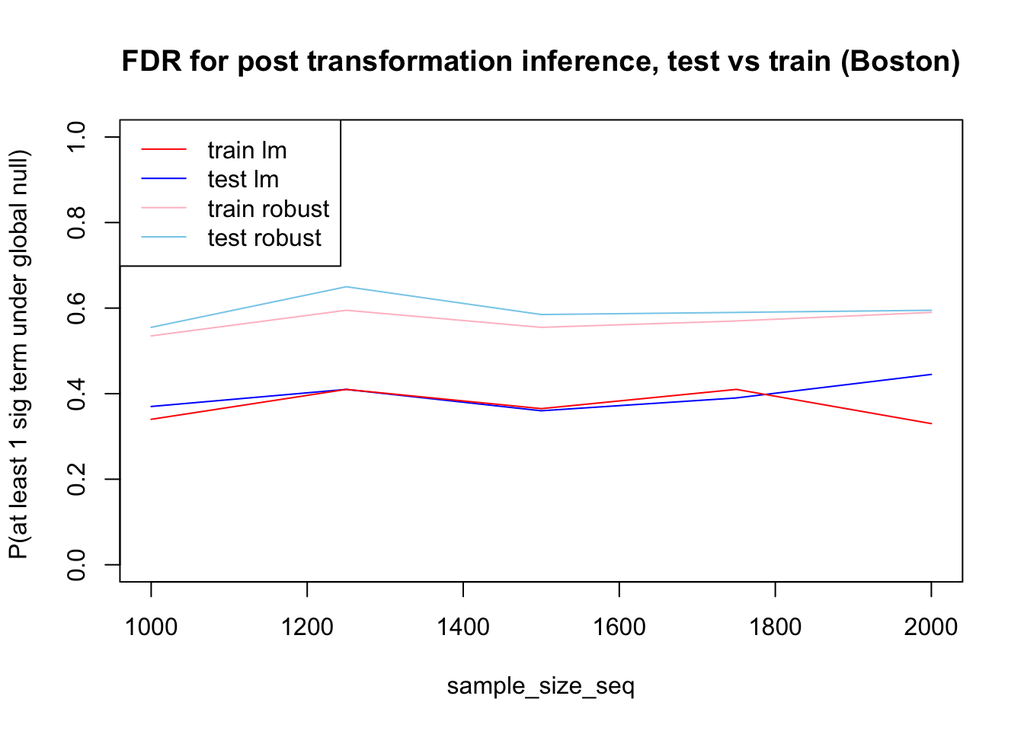

```r
#par(mfcol=c(2,1))
plot(sample_size_seq, test_prop, type = "l", col="blue", ylim = c(0,1), ylab = "P(at least 1 sig term under global null) ", main = "FDR for post transformation inference, test vs train (Boston)")
lines(sample_size_seq,train_prop, col="red")
lines(sample_size_seq,test_prop_sandwich, col="skyblue")
lines(sample_size_seq,train_prop_sandwich, col="pink")
legend("topleft", legend=c("train lm", "test lm", "train robust", "test robust"),col=c("red", "blue", "pink", "skyblue"), lty=1:1, cex=1)
```

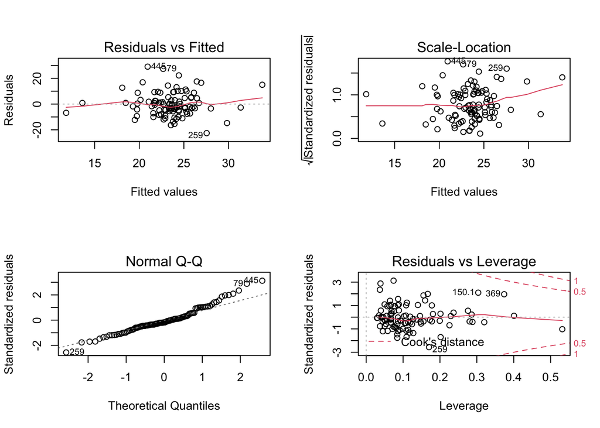

```r
par(mfcol=c(2,2))
plot(train_res[[sample(length(train_res),1)]])
```

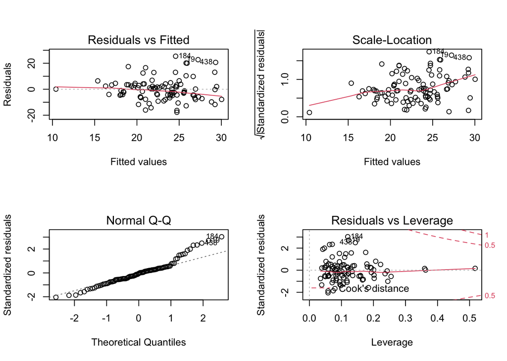

```r
plot(test_res[[sample(length(test_res),1)]])
```

## checking distributions of the betas

```r
var <- "nox"
par(mfcol=c(2,2))
betas_train <- unlist(purrr::map(train_res,get_coef_est,var))
names(betas_train) <- 1:B
hist(betas_train, breaks = 50, main = paste0("Distribution of ", var))
qqPlot(betas_train)
```

```
## [1] 67 64
```

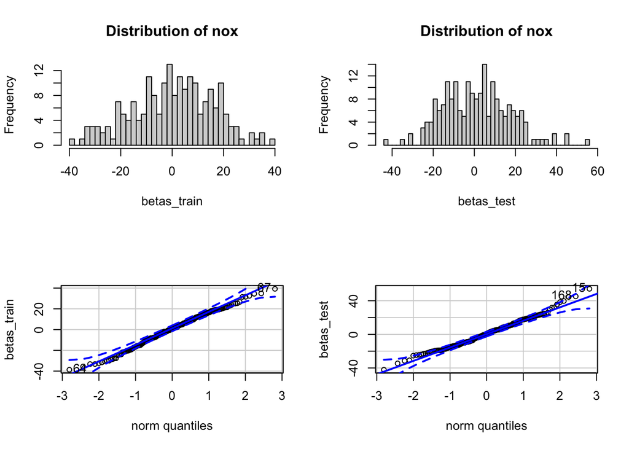

```
## [1]  15 168
```

```r
betas_test <- unlist(purrr::map(test_res,get_coef_est,var))
names(betas_test) <- 1:B
hist(betas_test, breaks = 50, main = paste0("Distribution of ", var))
qqPlot(betas_test)
```

```r
var <- "rad"
par(mfcol=c(2,2))
betas_train <- unlist(purrr::map(train_res,get_coef_est,var))
names(betas_train) <- 1:B
hist(betas_train, breaks = 50, main = paste0("Distribution of ", var))
qqPlot(betas_train)
```

```
## [1] 46 33
```

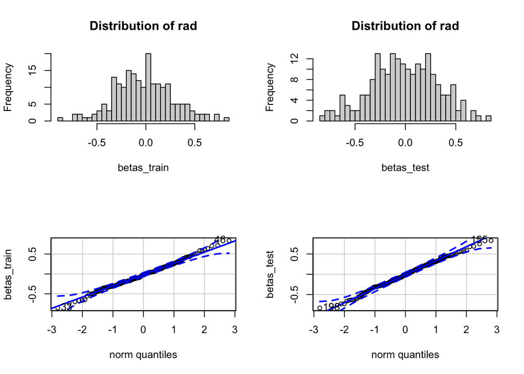

```
## [1] 155 198
```

```r
betas_test <- unlist(purrr::map(test_res,get_coef_est,var))
names(betas_test) <- 1:B
hist(betas_test, breaks = 50, main = paste0("Distribution of ", var))
qqPlot(betas_test)
```

```r
# dat$acpt <- (dat$acpt^(-2)/(-2))
# fit <- lm(rate~., data=Highway)
# fit<- CPMCGLM(as.formula(len~.), family="gaussian", link="identity", data=Highway, varcod="rate", boxcox=lambda_seq, N=100)
# summary(fit)
# bcPower(Highway, lambda = 2)
```